# Kde uspořádat demonstraci?

## sedmý <em>Prague R Meetup</em>

### <a href="mailto:jindra@jla-data.net">Jindra Lacko</a>

### <br>15.6.2018 @ KPMG

# Agenda

## Prostorová data (čím jsou jiná?)

## Erkové knihovny pro GIS práci

## Příklad - výpočet místa demonstrace

# Prostorová data

### Prostorová složka (*kde?*)

- bod = souřadnice X a Y
- čára = více bodů se začátkem a koncem
- polygon = více bodů spojených v pořadí
- rastr (speciální formát) = mřížka se začátkem a velikostí bloku

### Datová složka (*co?*)

- informace věcně svázaná s prostorovou složkou

### Příklad

- na souřadnicích X a Y roste strom, je to [smrk](https://cs.wikipedia.org/wiki/Smrk_ztepil%C3%BD) starý 25 let a napadený [kůrovcem](https://cs.wikipedia.org/wiki/L%C3%BDko%C5%BErout_smrkov%C3%BD)
- souřadnice XYZ ohraničují polygon, který má evidenční číslo LAU1 CZ0100, říkáme mu [Praha](https://cs.wikipedia.org/wiki/Praha) a žije v něm 1 294 513 obyvatel

# Souřadnicové systémy

### Zeměpisné

- poloha bodu na kouli vůči průsečíku rovníku a nultého poledníku v **úhlových** mírách (šířka, délka - zpravidla ve stupních)
- obecně platné (popisují povrch koule)
- příklad: [EPSG:4321](https://epsg.io/4326) - WGS84
- používá například Google Maps, GPS (geocashing)

### Plošné / Kartézské

- poloha bodu na ploše vůči počátku v **délkových** mírách (easting, northing - zpravidla v metrech)
- lokálně použitelné (zeměkoule *není* placatá; projekce je o kompromisech)
- příklad: [EPSG:5513](https://epsg.io/5513-1623) - inž. Křovák / S-JTSK
- obecně závazné pro geodezii, podmínka některých výpočtů

# package `sf`

Implementace [Simple Features](https://cs.wikipedia.org/wiki/Simple_Features) standardu prostorových dat v R.

### třída `sf`

- rozšiřuje `data.frame` = kombinuje datové sloupce a "navíc" speciální sloupec *geometry* s prostorovými atributy
- platí pro ni stejné funkce a techniky jako pro `data.frame` - například `dplyr::inner_join()` a `dplyr::filter()`
- objekty lze uložit do databáze (doporučuju [PostgreSQL](https://www.postgresql.org/)) a chovat se k nim jako k tabulárním datům

### funkce pro třídu `sf`

- `st_transform()` - přechází mezi souřadnicovými systémy
- `st_buffer()` - vrací okolí bodu / polygonu jako polygon
- `st_centroid()` - vrací střed polygonu jako bod
- `st_intersect()` - vrací průsečík dvou prostorových objektů
- a další ... :)

# package `tmap`

Nástroj pro tvorbu map - využívá formátu dat `sf` package.

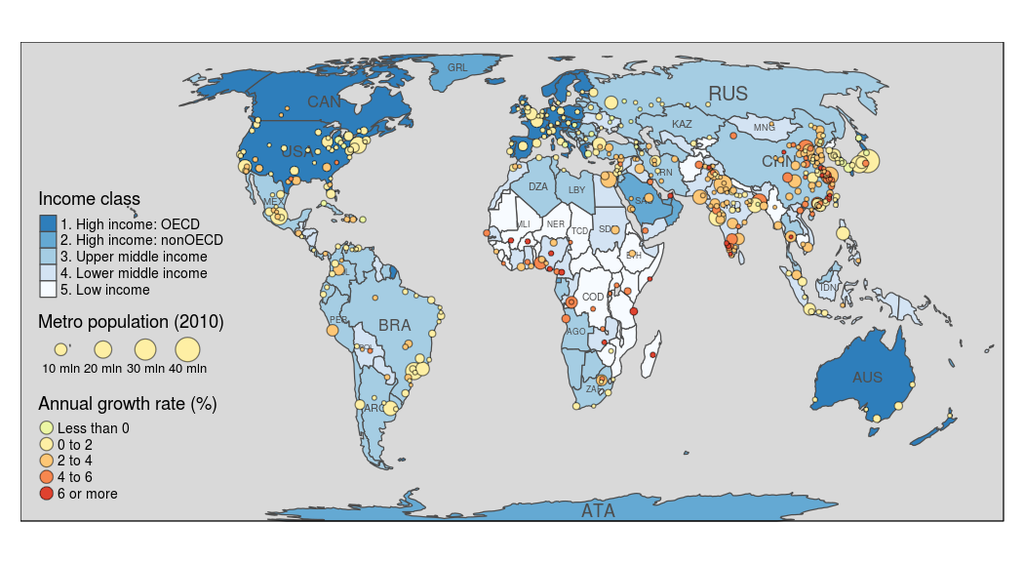